# challenge

Muqian Ye

2018/3/28

```r
library(dplyr)
library(maptools)
library(ggplot2)
```

```r
testoutcome <- read.csv("Testoutcome.csv", header = T, encoding = "UTF-8", na.strings = c("missing", "缺失"))
testitem <- read.csv("Testitem.csv", header = T, encoding = "UTF-8")
prerequisite <- read.csv("Prerequisite.csv", header = T)

colnames(testoutcome) <- c("city", "userId", "topicId", "topic", "userReportId", "conceptId", "concept", "master_char", "master")
colnames(testitem) <- c("city", "userId", "topicId", "topic", "userReportId", "examId", "series", "conceptId", "concept", "questionId", "question", "correct_char", "correct", "skip", "difficulty", "startTime", "endTime", "timespent")

attach(testoutcome)
testoutcome$userId <- as.factor(userId)
testoutcome$topicId <- as.factor(topicId)
testoutcome$userReportId <- as.factor(userReportId)
testoutcome$conceptId <- as.factor(conceptId)
detach()

attach(testitem)
testitem$userId <- as.factor(userId)
testitem$topicId <- as.factor(topicId)
testitem$userReportId <- as.factor(userReportId)
testitem$examId <- as.factor(examId)
testitem$conceptId <- as.factor(conceptId)
testitem$questionId <- as.factor(questionId)
detach()
```

## 描述性统计

### 用户数与测评数统计

```r
length(unique(testoutcome$userId))
```

```
## [1] 1863
```

```r
length(unique(testoutcome$userReportId))
```

```
## [1] 2235
```

```r
t <- unique(testoutcome[, c(2,5)])
t.user <- group_by(t, userId)
t.user.report <- summarise(t.user, n = n())
summary(t.user.report$n)
```

```
##    Min. 1st Qu.  Median    Mean 3rd Qu.    Max.
##     1.0     1.0     1.0     1.2     1.0    16.0
```

```r
sum(t.user.report$n==1)
```

```
## [1] 1631
```

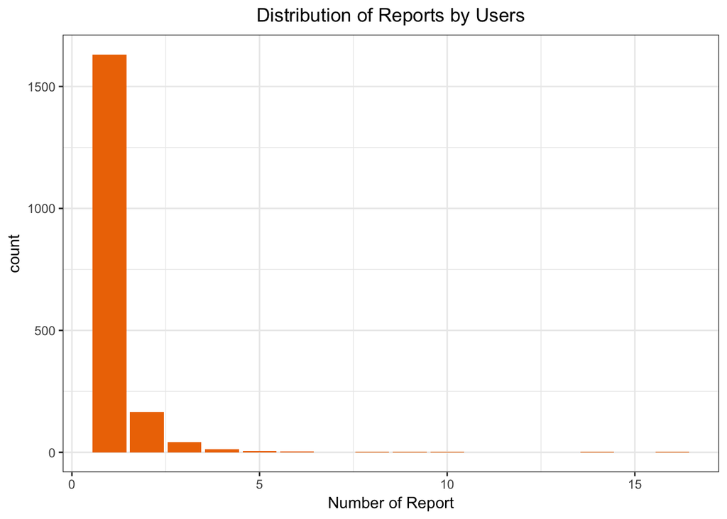

```r
ggplot(t.user.report, aes(x  = n)) +
  geom_bar(stat = 'count', fill="darkorange2") +
  theme_bw() +
  theme(plot.title = element_text(hjust= 0.5)) +
  labs(x = "Number of Report", title = "Distribution of Reports by Users")
```

共1863位测评者，2235份测评报告。其中1631位用户只做了一次测评。最多的一位用户做了16次测评。

### 用户地域分布

```r
t <- unique(testoutcome[, c(1,2)])
sum(t$city=="NULL")
```

```
## [1] 63
```

```r
t <- t[t$city!="NULL", ]
t.city <- group_by(t, city)
t.user.city <- summarise(t.city, n = n())

summary(t.user.city$n)
```

```
##    Min. 1st Qu.  Median    Mean 3rd Qu.    Max.
##    1.00    1.00    3.00    6.87    8.00  119.00
```

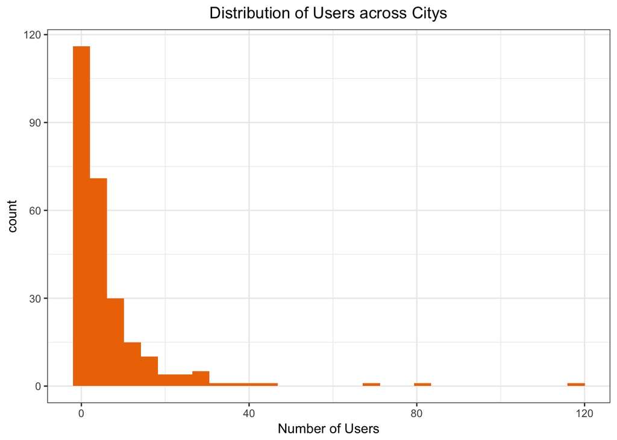

```r
ggplot(t.user.city, aes(x  = n)) +
  geom_histogram(fill="darkorange2") +
  theme_bw() +
  theme(plot.title = element_text(hjust= 0.5)) +
  labs(x = "Number of Users", title = "Distribution of Users across Citys")
```

除去63位位置信息不明的用户，其余用户来自262个城市。测评者最多的城市是北京，共有119位测评者。

```r
province <- read.csv("province.csv", header = T, encoding = "UTF-8")
colnames(province) <- c("province", "city")
t.province <- left_join(t, province, by = "city")
t.province[which(t.province$city=="吉林"), 3] <- "吉林省"
t.province <- t.province[!is.na(t.province$province), ]

t.province <- group_by(t.province, province)
t.user.prov <- summarise(t.province, n = n())

summary(t.user.prov$n)
```

```
##    Min. 1st Qu.  Median    Mean 3rd Qu.    Max.
##    1.00   20.00   35.50   59.27   88.25  203.00
```

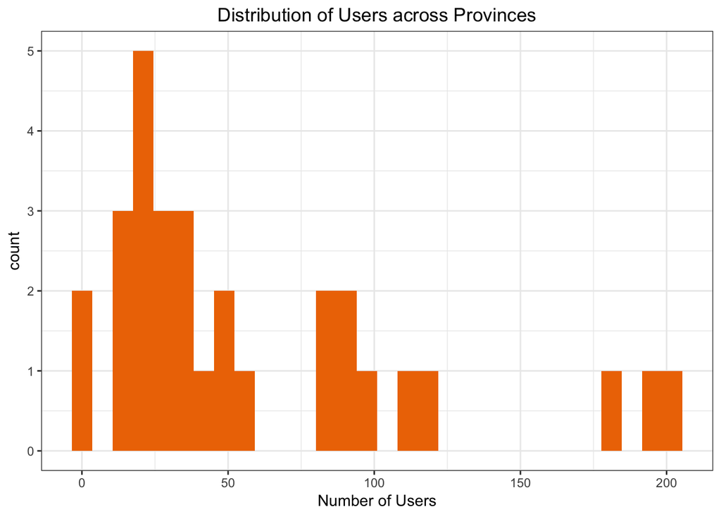

```r
ggplot(t.user.prov, aes(x  = n)) +
  geom_histogram(fill="darkorange2") +
  theme_bw() +
  theme(plot.title = element_text(hjust= 0.5)) +
  labs(x = "Number of Users", title = "Distribution of Users across Provinces")
```

[figure not shown]

```r
ggplot(data = t.user.prov, mapping = aes(x = factor(province), y = n)) +
  geom_bar(stat= 'identity', position = 'dodge',fill="darkorange2") +
  labs(x = "Province", y = "count", title = "Distribution of Users across Provinces") +
  theme(plot.title = element_text(hjust= 0.5))
```

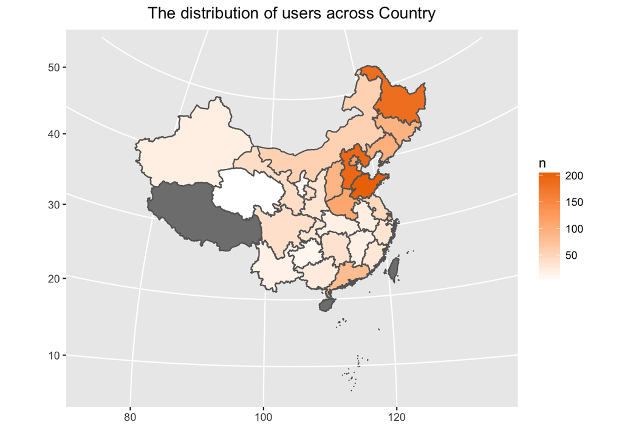

```r
china_map = readShapePoly('bou2_4p.shp')
china_map@data$NAME <- as.character(iconv(china_map@data$NAME,"GBK","UTF-8"))

data1<- china_map@data
data2<- data.frame(id=row.names(data1), data1)
china_map1 <- fortify(china_map)
china_map_data <- full_join(china_map1, data2)

prov <- t.user.prov
colnames(prov)[1]<-"NAME"
china_data <- full_join(china_map_data, prov)
ggplot(china_data, aes(x = long, y = lat, group = group, fill = n)) +
  geom_polygon(colour="grey40") +
  scale_fill_gradient(low="white",high="darkorange2") +
  coord_map("polyconic") +
  labs(x = "", y = "" , title = "The distribution of users across Country") +
  theme(plot.title = element_text(hjust= 0.5))
```

### 测评的出题数分布

```r
unique(testitem$conceptId)
```

```
##  [1] 2015005 2015012 2015003 2015004 2015010 2015007 2015011 2015008
##  [9] 2019001 2015009 2015006 2015001 2015013 2019002 2015002 2015015
## [17] 2015014 2019003
## 18 Levels: 2015001 2015002 2015003 2015004 2015005 2015006 ... 2019003
```

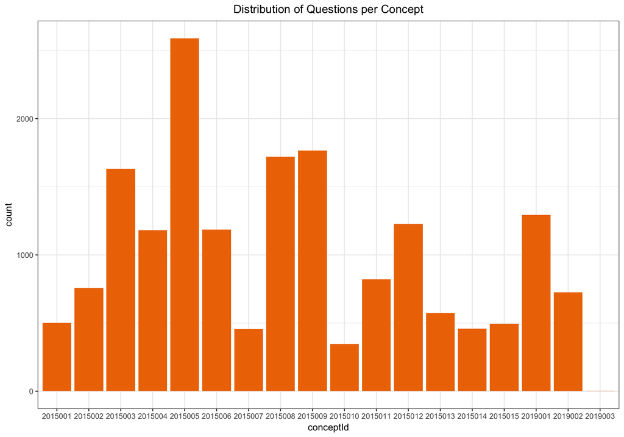

```r
ggplot(testitem, aes(x  = conceptId)) +
  geom_bar(stat = 'count', fill="darkorange2") +
  theme_bw() +
  theme(plot.title = element_text(hjust= 0.5)) +
  ggtitle('Distribution of Questions per Concept')
```

### 知识点的掌握率统计

```r
ind <- which(!is.na(testoutcome$master))
t.master <- testoutcome[ind, c(6, 9)]
t.master <- group_by(t.master, conceptId)
t.user.master <- summarise(t.master, n = n(), sumMaster = sum(master))
t.user.master <- mutate(t.user.master, rate = sumMaster/n)
t.user.master
```

```
## # A tibble: 18 x 4
##    conceptId     n sumMaster     rate
##    <fct>     <int>     <int>    <dbl>
##  1 2015001    2139      1760 0.823
##  2 2015002    2054      1579 0.769
##  3 2015003    2235      1257 0.562
##  4 2015004    2235      1274 0.570
##  5 2015005    2235      1053 0.471
##  6 2015006    2051       773 0.377
##  7 2015007    2054       840 0.409
##  8 2015008    2028       587 0.289
##  9 2015009    2235       664 0.297
## 10 2015010    2185       484 0.222
## 11 2015011    1903      1247 0.655
## 12 2015012    1650       793 0.481
## 13 2015013    2176       370 0.170
## 14 2015014    2082       217 0.104
## 15 2015015    2075      1856 0.894
## 16 2019001    2235       379 0.170
## 17 2019002    2235       221 0.0989
## 18 2019003    2015         1 0.000496
```

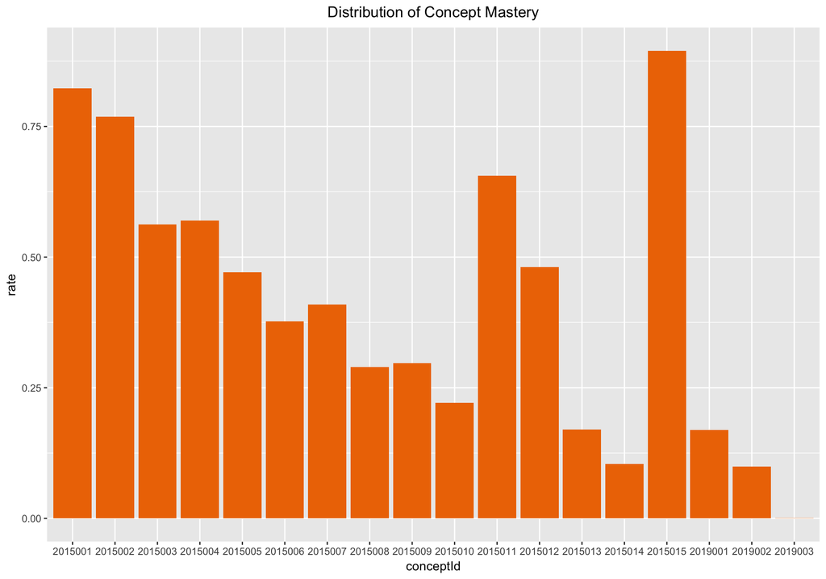

```r
ggplot(data = t.user.master, mapping = aes(x = factor(conceptId), y = rate)) +
  geom_bar(stat= 'identity', position = 'dodge',fill="darkorange2") +
  labs(x = "conceptId", y = "rate", title = "Distribution of Concept Mastery") +
  theme(plot.title = element_text(hjust= 0.5))
```

### 测评答题正确率统计

```r
length(unique(testitem$questionId))
```

```
## [1] 387
```

```r
t.correct <- testitem[, c(10, 13)]
t.correct <- group_by(t.correct, questionId)
t.user.correct <- summarise(t.correct, n = n(), sumCorrect = sum(correct))
t.user.correct <- mutate(t.user.correct, rate = sumCorrect/n)
summary(t.user.correct$rate)
```

```
##    Min. 1st Qu.  Median    Mean 3rd Qu.    Max.
##  0.0000  0.2500  0.3944  0.4209  0.5817  1.0000
```

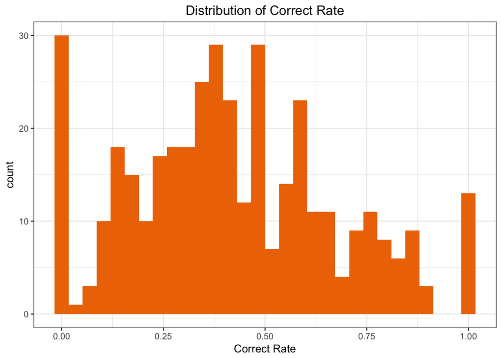

```r
ggplot(t.user.correct, aes(x  = rate)) +
  geom_histogram(fill="darkorange2") +
  theme_bw() +
  theme(plot.title = element_text(hjust= 0.5)) +
  labs(x = "Correct Rate", title = "Distribution of Correct Rate")
```

```r
difficult <- unique(testitem[, c(10, 15)])
t.ques.diff <- full_join(t.user.correct, difficult)
t.ques.diff$difficulty <- as.factor(t.ques.diff$difficulty)

bartlett.test(rate ~ difficulty, data = t.ques.diff)
```

```
##
##  Bartlett test of homogeneity of variances
##
## data:  rate by difficulty
## Bartlett's K-squared = 0.14249, df = 2, p-value = 0.9312
```

```r
rate.diff <- aov(rate ~ difficulty, data = t.ques.diff)
summary(rate.diff)
```

```
##              Df Sum Sq Mean Sq F value Pr(>F)
## difficulty    2   0.35 0.17511   2.801  0.062 .
## Residuals   384  24.01 0.06252
## ---
## Signif. codes:  0 '***' 0.001 '**' 0.01 '*' 0.05 '.' 0.1 ' ' 1
```

```r
TukeyHSD(rate.diff)
```

```
##   Tukey multiple comparisons of means
##     95% family-wise confidence level
##
## Fit: aov(formula = rate ~ difficulty, data = t.ques.diff)
##
## $difficulty
##            diff        lwr           upr     p adj
## 2-1 -0.04145520 -0.1159931  0.0330827165 0.3912471
## 3-1 -0.08028067 -0.1601551 -0.0004062537 0.0485218
## 3-2 -0.03882547 -0.1091400  0.0314890219 0.3965056
```

目前出现的共有387道不同的题，平均正确率约为0.4。 不同难度题目的正确率有无差别，首先用bartlett检验考察，符合方差齐次性，因此可以进行方差分析，结果显示组间差距不是很明显，进一步用多重比较进行分析，发现相邻难度之间的正确率没有显著差异，但是难度为1的题和难度为3的题之间的正确率差别就很大了。

### 答题时间分析

timespent应该为startTime和endTime之间的时间差，但是由于十进制运算产生了错误，所以重新计算该变量。

```r
summary(testitem$timespent)
```

```
##      Min.   1st Qu.    Median      Mean   3rd Qu.      Max.
##         0         5        13     38954        48 196824924
```

```r
startTime <- as.POSIXct(as.character(testitem$startTime), format = '%m/%d/%Y %H:%M:%S')
endTime <- as.POSIXct(as.character(testitem$endTime), format = '%m/%d/%Y %H:%M:%S')
timespent <- as.numeric(difftime(endTime, startTime, units="secs"))
summary(timespent)
```

```
##    Min. 1st Qu.  Median    Mean 3rd Qu.    Max.
##       0       5      11     949      22 4772964
```

```r
testitem$startTime <- startTime
testitem$endTime <- endTime
testitem$timespent <- timespent

sum(testitem$correct[timespent < 5]) / sum(timespent < 5)
```

```
## [1] 0.2768296
```

```r
summary(timespent[timespent >= 5])
```

```
##    Min. 1st Qu.  Median    Mean 3rd Qu.    Max.
##       5       9      15    1249      27 4772964
```

```r
27 + 1.5 * (27 - 5)
```

```
## [1] 60
```

```r
sum(testitem$correct[timespent >= 5 & timespent < 1000]) / sum(timespent >= 5 & timespent < 1000)
```

```
## [1] 0.4782349
```

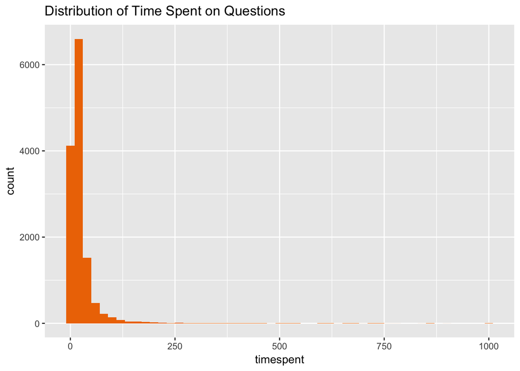

```r
ggplot(testitem[timespent >= 5 & timespent < 1000,], aes(x = timespent)) +
  stat_bin(fill="darkorange2", binwidth = 20) +
  ggtitle('Distribution of Time Spent on Questions')
```

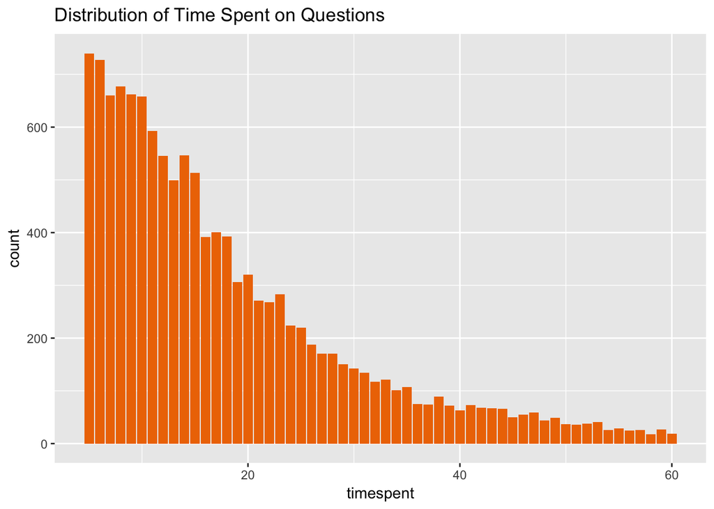

```r
ggplot(testitem[timespent >= 5 & timespent <= 60,], aes(x = timespent)) +
  geom_bar(fill="darkorange2") +
  ggtitle('Distribution of Time Spent on Questions')
```

### 测评用时分析

```r
t <- testitem[, c(6, 16, 17)]
t.test <- group_by(t, examId)
t.testtime <- summarise(t.test, start = min(startTime), end = max(endTime))
t.testtime <- mutate(t.testtime, timeused = as.numeric(difftime(end, start, units="secs")))
summary(t.testtime$timeused)
```

```
##    Min. 1st Qu.  Median    Mean 3rd Qu.    Max.
##       8      63     123    7531     207 4773190
```

```r
207 + 1.5 * (207 - 63)
```

```
## [1] 423
```

```r
sum(t.testtime$timeused > 423)
```

```
## [1] 174
```

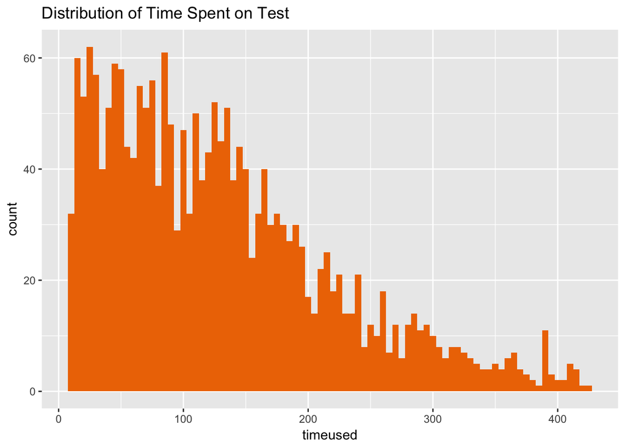

```r
ggplot(t.testtime[t.testtime$timeused <= 423,], aes(x = timeused)) +
  geom_bar(binwidth = 5, fill="darkorange2") +
  ggtitle('Distribution of Time Spent on Test')
```

### 测评数据中体现出了多少种不同的知识点路径

```r
library(reshape2)
t.test.concept <- testitem[,c(5,7,8)]
t.test.concept <- dcast(t.test.concept, userReportId ~ series + conceptId)
dim(unique(t.test.concept[,-1]))
```

```
## [1] 475 142
```

在2235次测评中，不同的知识点路径数共有475种。

### 测评数据中体现出了多少种不同的做题路径

```r
t.test.question <- testitem[,c(5,7,10)]
t.test.question <- dcast(t.test.question, userReportId ~ series + questionId)
dim(unique(t.test.question[,-1]))
```

```
## [1] 2205 1931
```

不同的做题路径数共有2205种。

## 案例分析

在这个部分，选取4511号同学的数据进行分析。

### 该学生的答题数和正确率

```r
studentitem <- testitem[which(testitem$userId=="4511"), ]
length(unique(studentitem$questionId))
```

```
## [1] 89
```

```r
sum(studentitem$correct) / dim(studentitem)[1]
```

```
## [1] 0.7857143
```

这位同学一共答了126道题，其中删去重复的一共是89题。该同学总体的答题正确率为78.57%。

### 掌握和未掌握的知识点数目

```r
studentoutcome <- testoutcome[which(testoutcome$userId=="4511"), ]

length(unique(studentoutcome$conceptId))
```

```
## [1] 18
```

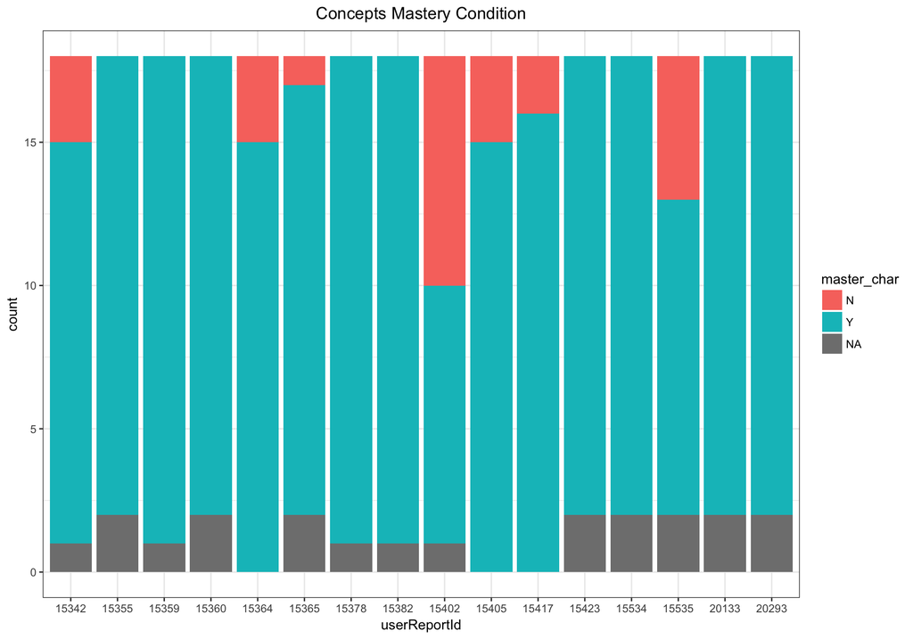

```r
ggplot(studentoutcome, aes(x  = userReportId, fill = master_char)) +
  geom_bar() +
  theme_bw() +
  theme(plot.title = element_text(hjust= 0.5)) +
  ggtitle('Concepts Mastery Condition')
```

### 有多少知识点未做题被智能推断为掌握或者未掌握，是否合理?

```r
t.student <- group_by(studentitem, userReportId)
t.stu.concept <- summarise(t.student, n = length(unique(conceptId)))
summary(t.stu.concept$n)
```

```
##    Min. 1st Qu.  Median    Mean 3rd Qu.    Max.
##   4.000   4.000   5.000   5.062   5.250   7.000
```

```r
# t.student <- mutate(t.student, )
t.stu.wrong <- studentitem[studentitem$correct == 0, c(5, 8)]
```

每次测评一般只考察4～7个知识点，其余11～14个知识点都是智能推断的。

### 有多少知识点被反复测试(做了两道或者三道题)，是否合理?

```r
t.stu.repeat <- group_by(studentitem, userReportId, conceptId)
t.stu.rep <- summarise(t.stu.repeat, n = n())
t.stu.rep[t.stu.rep$n>1, ]
```

```
## # A tibble: 35 x 3
## # Groups:   userReportId [16]
##    userReportId conceptId     n
##    <fct>        <fct>     <int>
##  1 15342        2015013       2
##  2 15342        2019001       3
##  3 15355        2019001       3
##  4 15359        2015014       2
##  5 15359        2019002       2
##  6 15360        2015013       2
##  7 15360        2019002       3
##  8 15364        2015009       2
##  9 15364        2015010       2
## 10 15364        2015014       2
## # ... with 25 more rows
```

```r
length(unique(t.stu.rep$conceptId))
```

```
## [1] 11
```

### 对分数与比的知识图谱进行可视化呈现

```r
library(networkD3)
x1 <- prerequisite[which(!is.na(prerequisite[,2])), c(2, 1)]
x2 <- prerequisite[which(!is.na(prerequisite[,3])), c(3, 1)]
x3 <- prerequisite[which(!is.na(prerequisite[,4])), c(4, 1)]
names(x1) <- c("concept", "prerequisite")
names(x2) <- c("concept", "prerequisite")
names(x3) <- c("concept", "prerequisite")
networkData <- bind_rows(x1, x2, x3)

simpleNetwork(networkData, zoom = TRUE)
```

[interactive chart not shown]

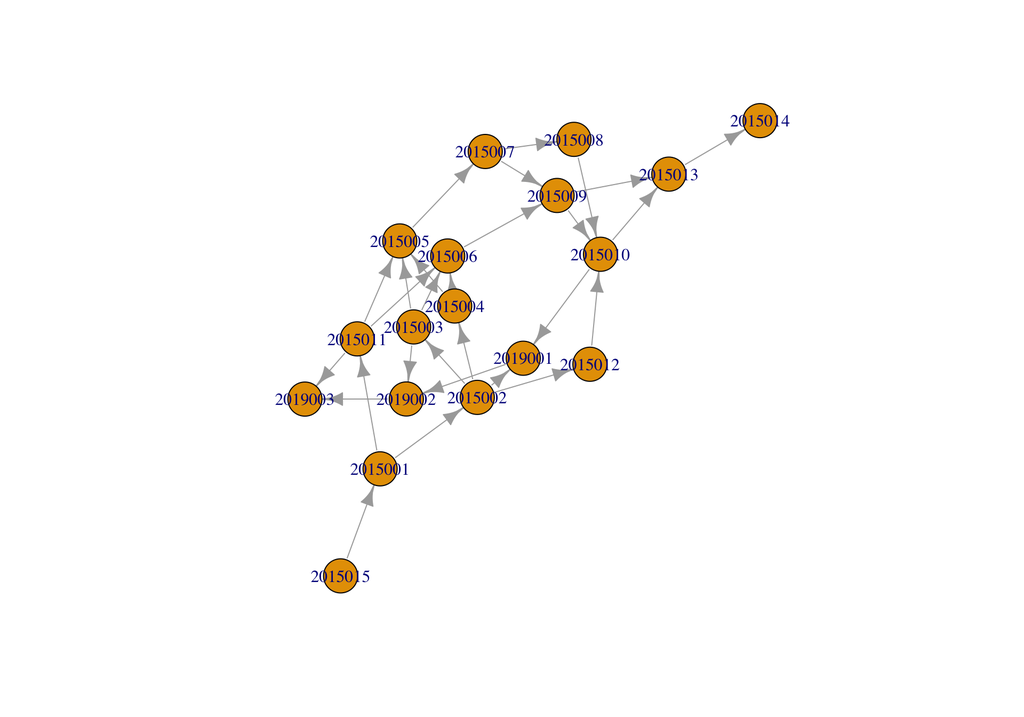

```r
library(igraph)
concept <- unique(studentoutcome[,c(6,7)])
names(networkData) <- c("to", "from")
g <- graph_from_data_frame(networkData, directed=TRUE, vertices=concept)
plot(g)
```

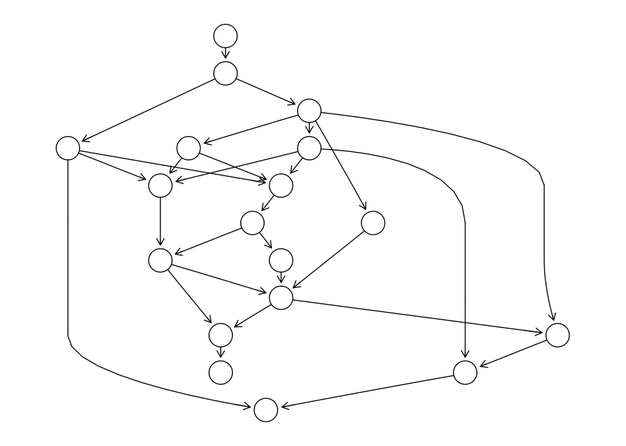

```r
library(bnlearn)
library(Rgraphviz)

KnowledgeMap = as.matrix(read.csv("Prerequisite.csv", header = F, skip = 1))

cl=as.character(KnowledgeMap[,1])
nc=length(cl)
np=dim(KnowledgeMap)[2]

KG <- new("graphNEL", nodes=cl, edgemode="directed")

for (i in 1:nc) {
  for (j in 2:np) {

if (!is.na(KnowledgeMap[i,j]))
{
  KG <- addEdge(as.character(KnowledgeMap[i,j]),cl[i], KG, 1)
}
  }
}

nAttrs <- list()
#color=c(rep("skyblue",5),rep("lightgreen",6),rep("yellow",3),rep("pink",5))
color=rep("white",nc)
nAttrs$fillcolor <- color
names(nAttrs$fillcolor)=cl

par(family='STKaiti')
plot(KG, nodeAttrs=nAttrs,main="")
```

### 对该学生测评过程的知识点路径进行可视化

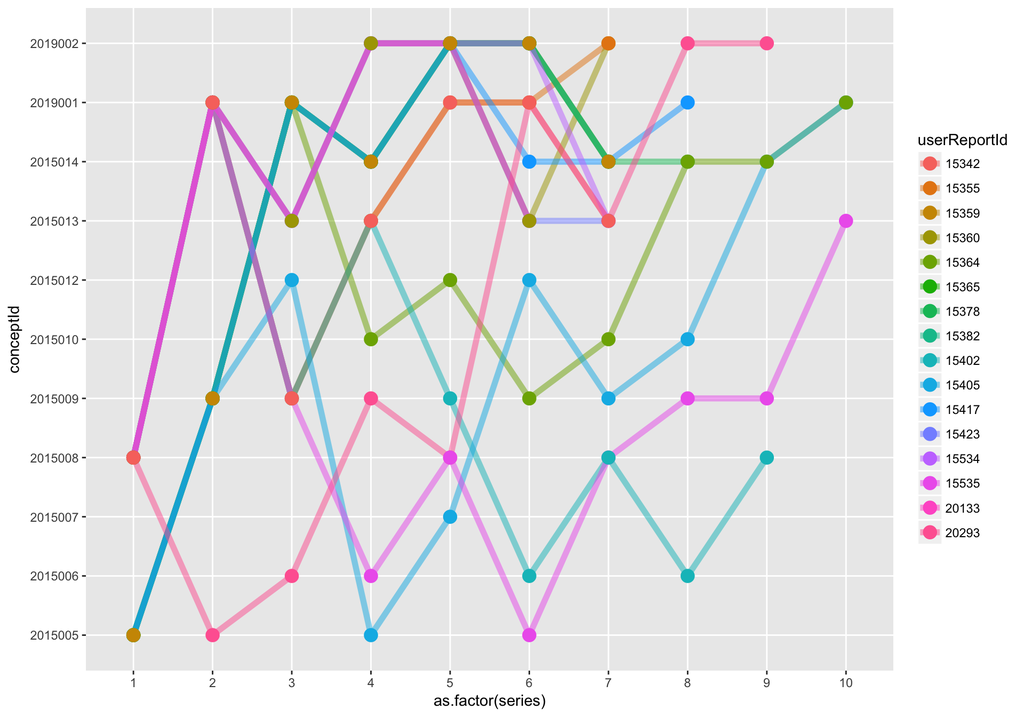

```r
ggplot(studentitem, aes(x = as.factor(series), y = conceptId, colour = userReportId, group=userReportId)) +
  geom_line(size=2, alpha = 0.5) +
  geom_point(size=4)
```

### 对该学生测评结果的知识状态进行可视化

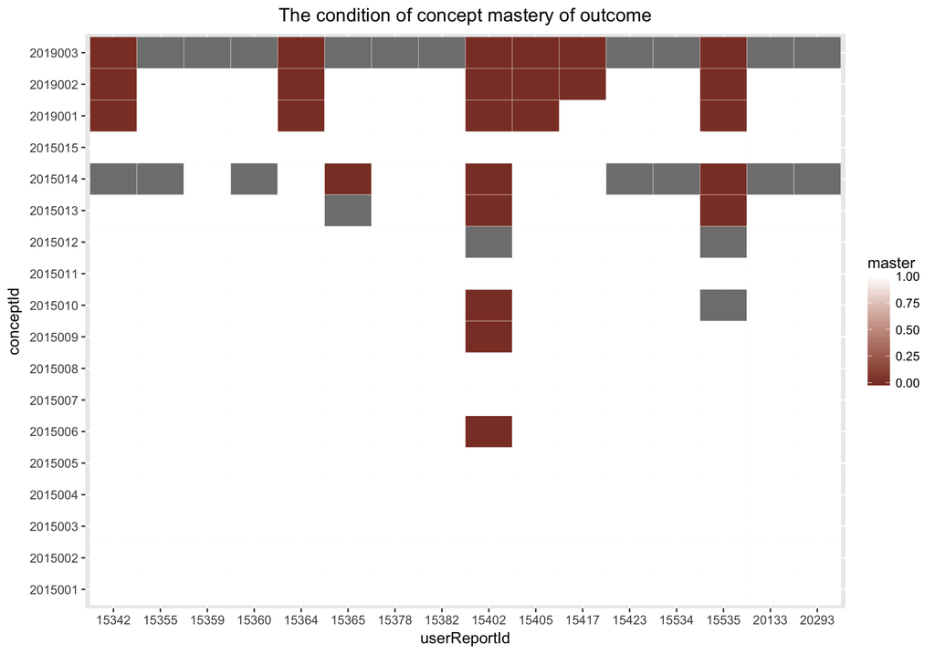

```r
base_size <- 12
outcome_concept <- ggplot(studentoutcome, aes(userReportId, conceptId))+
  geom_tile(aes(fill = master), colour = "white")+
  scale_fill_gradient(low = "coral4", high = "white")+
  theme_grey(base_size = base_size)+
  labs(x = "userReportId", y = "conceptId" , title = "The condition of concept mastery of outcome")+
  theme(plot.title = element_text(hjust = 0.5))
print(outcome_concept)
```

### 基于测评结果，你会给老师什么样的教学建议?

加强比值知识点的学习

## 知识图谱迭代

### 一共有多少种知识状态?

2**18

### 其中有多少种可行知识状态?

50

### 如何基于测评数据分析两个知识点间是否有前提关系以及关系强弱?

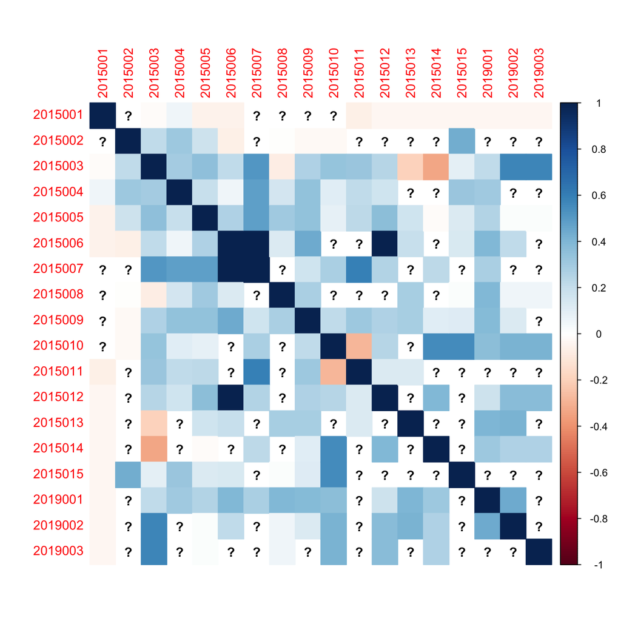

```r
library(corrplot)
test.concept <- testitem[which(testitem$timespent >= 5 & testitem$timespent <= 60), c(5, 8, 13)]

test.concept <- group_by(test.concept, userReportId, conceptId)
t.test.concept <- summarise(test.concept, n = n(), sumCorrect = sum(correct))
t.test.concept <- mutate(t.test.concept, rate = sumCorrect/n)

t.concept.rate <- dcast(t.test.concept, userReportId~conceptId, value.var = "rate")

corr.concept <- cor(t.concept.rate[,-1])
for (i in 1:17){
  for (j in (i+1):18){
    try(c <- cor(t.concept.rate[, c(i+1, j+1)], use = "complete.obs"), silent = T)
    try(corr.concept[i, j] <- c[1,2], silent = T)
    try(corr.concept[j, i] <- c[2,1], silent = T)

  }
}

corrplot(corr.concept, method = "color")
```

只取有效结果进行分析，首先计算每次测评中各个知识点的答题正确率，然后两两计算相关系数。 比如2015006和2015007以及2015012就有很强的相关性。如果数据足够多效果会更好。 但是缺少因果关系。

结合Prerequisite来看，7和6没有直接因果关系，但是7的前置要求5和6所拥有的前置条件是一模一样的。7和12也是一样，没有直接的联系，但是共有最底层的前置条件。

### 你会对当前知识图谱做怎么样的迭代?

知识图谱可以不只有前后因果关系，还可以把相似的，学生容易一起掌握或者比较难攻克的知识点做一个整合。目前的知识图谱只限于相关学习单元，但追根溯源掌握情况可能由更基础的知识点决定。